# Dynamic decision making with predictive panels

This notebook is a companion material to the article **Dynamic decision making with predictive panels** by Guillaume Coqueret and Bertrand Tavin.  
The **code** is **folded** to lighten the presentation, but can be accessed by clicking on the corresponding unfolding buttons.  
It corresponds to the second exercise in the paper, for which the data is public.

# 1 Packages

First, we load the required packages.

```r
if(!require(tidyverse)){install.packages(c("tidyverse", "lubridate", "nlshrink", "broom", "gt"))}
library(tidyverse)  # Data handling
library(lubridate)  # Date handling
library(patchwork)  # Graph layout
library(nlshrink)   # Shrinkage estimators
library(broom)      # Regression output (tidy)
library(texreg)     # LaTeX regression output
library(latex2exp)  # LaTeX in ggplot
library(gt)         # Neat tables
```

# 2 Data

Second, we download & format the data, which comes from [Ken French’s Data Library](https://mba.tuck.dartmouth.edu/pages/faculty/ken.french/data_library.html).  
We work with the 10 industry portfolios, sampled at the daily frequency.  
**NOTE**: depending on the files, the number of rows to skip (when reading the .csv file) changes. It typically varies between 2 and 10.

We drop the data before 1980 but it’s easy to consider 1950 onwards.

```r
temp <- tempfile()
link <- "http://mba.tuck.dartmouth.edu/pages/faculty/ken.french/ftp/10_Industry_Portfolios_daily_CSV.zip"

download.file(link, temp, quiet = TRUE)                       # Download!
df_assets <- read_csv(unz(temp, "10_Industry_Portfolios_Daily.csv"),  skip = 9) %>%
    # Check the nb of lines to skip
    rename(Date = `...1`) %>%                                 # Change name of the first column
    mutate_at(vars(-Date), as.numeric) %>%                    # Convert to number
    mutate_at(vars(-Date), function(x){x/100}) %>%            # Divide by 100
    mutate(Date = ymd(parse_date_time(Date, "%Y%m%d")))       # End of month date
split <- which(is.na(df_assets$Date))[1]                      # Split between portfolio types!
df_assets <- df_assets[1:(split-1),]
df_assets <- df_assets %>% filter(year(Date) >= 1980)         # Choose a period (after 1950: more reliable)

colnames(df_assets)[1] <- "date"
stock_ids <- colnames(df_assets[,c(2:ncol(df_assets))])       # List of assets
nb_assets <- length(stock_ids)                                # Number of assets
list_years <- c(1980:2022)                                    # List of years considered
```

# 3 Main function

Note: it allows for sample versus shrinkage estimators (see last argument of the function).

```r
time_series_output <- function(nb_assets, df_assets, sample_size, shrinkage){ # The main function

    one_n <- as.matrix(rep(1,nb_assets))            # A vector of ones
    nb_dates <- length(df_assets$date)              # The number of dates
    list_daily_dates <- df_assets$date              # List of these dates

    Sigma_is <- list()                              # Initializing the variables
    Sigma_oos <- list()
    inv_Sigma_is <- list()
    inv_Sigma_oos <- list()
    vec_mu_is <- list()
    vec_mu_oos <- list()

    nb_t <- sample_size * 21                        # Or: 500 # 252 # Length of samples (is & oos)
    t0 <- nb_t                                      # start date
    step_lgth <- 21

    nb_points <- (nb_dates - 2*nb_t) %/% step_lgth  # Max number of monthly steps in the dataset
    tend <- t0 + step_lgth*nb_points
    one_t <- as.matrix(rep(1,nb_t))
    date_list <- as.Date(df_assets[t0+nb_t,]$date)

    for(j in 1:nb_points){
        n_start_is <- t0+(j-1)*step_lgth - nb_t + 1
        n_end_is <- t0+(j-1)*step_lgth
        n_start_oos <- t0+(j-1)*step_lgth + 1       # Out-of-sample starts the day after
        n_end_oos <- t0+(j-1)*step_lgth + nb_t
        date_list[j] <- as.Date(df_assets[n_end_is,]$date)

        # In-sample
        data_temp_is <- df_assets[c(n_start_is:n_end_is),]
        if(shrinkage == TRUE){
            Sigma_is[[j]] <- linshrink_cov(X = as.matrix(data_temp_is[stock_ids]))
        } else {
            Sigma_is[[j]] <- var(data_temp_is[stock_ids])                 # Sigma_is = X'X
        }
        vec_mu_is[[j]] <- as.matrix(colMeans(data_temp_is[stock_ids]))    # v_is = X'y
        inv_Sigma_is[[j]] <- solve(Sigma_is[[j]])                         # Sigma_is^{-1}

        # Out-of-Sample
        data_temp_oos <- df_assets[c(n_start_oos:n_end_oos),]
        if(shrinkage == TRUE){
            Sigma_oos[[j]] <- linshrink_cov(X = as.matrix(data_temp_oos[stock_ids]))
        } else {
            Sigma_oos[[j]] <- var(data_temp_oos[stock_ids])
        }
        vec_mu_oos[[j]] <- as.matrix(colMeans(data_temp_oos[stock_ids]))
        inv_Sigma_oos[[j]] <- solve(Sigma_oos[[j]])

    }

    loss_series <- 0 # SSR
    dt_series <- 0
    Deltat_series <- 0

    for(j in 1:nb_points){
        loss_series[j] <- t(vec_mu_is[[j]]) %*% inv_Sigma_is[[j]] %*% Sigma_oos[[j]] %*% inv_Sigma_is[[j]] %*% vec_mu_is[[j]] -
            2 * t(vec_mu_is[[j]]) %*% inv_Sigma_is[[j]] %*% vec_mu_oos[[j]] +
            t(vec_mu_oos[[j]]) %*% inv_Sigma_oos[[j]] %*% vec_mu_oos[[j]]
        Deltat_series[j] <- 0.00001*norm(inv_Sigma_is[[j]] - inv_Sigma_oos[[j]], type = "2")  # Covariate shift
        dt_series[j] <- 10*sum(abs(vec_mu_is[[j]] - vec_mu_oos[[j]]))                         # Concept drift
    }

    output <- list(date_list = date_list, L = loss_series, d_t = dt_series, Delta_t = Deltat_series)
    return(output)
} # End of function
```

Then, we gather the estimates for the loss $L$, the drift $d_t$ and the shift $D_t$.

```r
shrink_k <- TRUE # With shrinkage

fct_output1m <- time_series_output(nb_assets, df_assets, 1, shrink_k)
output1m <- data.frame(date = fct_output1m$date_list,
                       L = fct_output1m$L,
                       d_t = fct_output1m$d_t,
                       D_t = fct_output1m$Delta_t)
fct_output3m <- time_series_output(nb_assets, df_assets, 3, shrink_k)
output3m <- data.frame(date = fct_output3m$date_list,
                       L = fct_output3m$L,
                       d_t = fct_output3m$d_t,
                       D_t = fct_output3m$Delta_t)
fct_output6m <- time_series_output(nb_assets, df_assets, 6, shrink_k)
output6m <- data.frame(date = fct_output6m$date_list,
                       L = fct_output6m$L,
                       d_t = fct_output6m$d_t,
                       D_t = fct_output6m$Delta_t)
```

# 4 Graph

Finally, we plot the results.

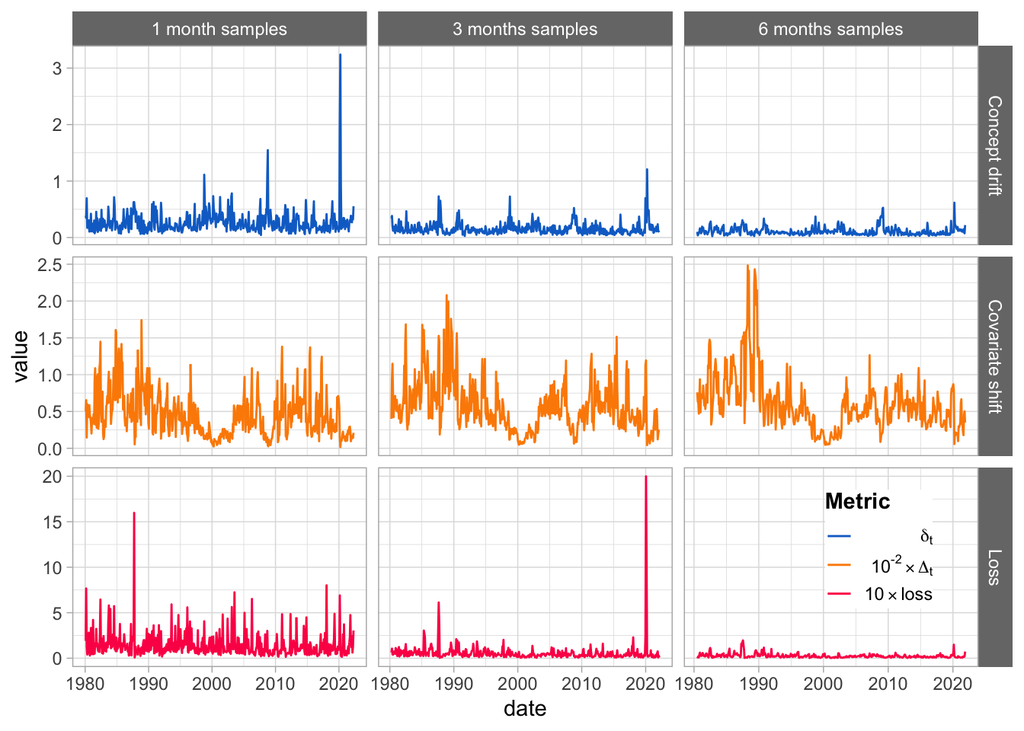

```r
bind_rows(bind_cols(output1m, sample ="1 month"),
          bind_cols(output3m, sample ="3 month"),
          bind_cols(output6m, sample ="6 month")) %>%
    pivot_longer(-c(date, sample), names_to = "indicator", values_to = "value") %>%
    ggplot(aes(x = date, y = value, color = indicator)) + geom_line() + theme_light() +
    facet_grid(indicator~sample, scales = "free",
               labeller = labeller(indicator = c(D_t = "Covariate shift", d_t = "Concept drift", L = "Loss"),
                                 sample = c(`1 month` = "1 month samples",
                                            `3 month` = "3 months samples",
                                            `6 month` = "6 months samples"))) +
    scale_color_manual(values = c("#0D70CD", "#FC8B02", "#FC0255"),
                       labels = unname(TeX(c("$\\delta_t$", "$10^{-2} \\times\\Delta_t$", "$10\\times loss$"))),
                       name = "Metric") +
    theme(legend.position = c(0.89,0.19),
          strip.background =element_rect(fill="#777777"),
          legend.spacing = unit(-0.6, "cm"), legend.key.size = unit(0.5, "cm"),
          legend.margin = unit(-0.6, "cm"), legend.title = element_text(size = 11, face = "bold"),
          legend.box.spacing = unit(-0.6, "cm"))
```

```r
# ggsave("ts2.pdf", width = 8, height = 5)
```

# 5 Regression analysis

Regression analysis: Loss in terms of SSR Regressed against covariate shift and concept drift, both squared + cross term.

## 5.1 One month samples

First, the dataset where all is stored. We start with one month samples for the estimators.

```r
data_reg1m <- data.frame(date = fct_output1m$date_list,
                         D_t2 = (fct_output1m$Delta_t*100)^2,           # Scaled
                         d_t2 = (fct_output1m$d_t)^2,
                         D_t_dt = fct_output1m$Delta_t*fct_output1m$d_t,
                         D_t = fct_output1m$Delta_t,
                         d_t = fct_output1m$d_t,
                         loss = fct_output1m$L)
```

Next, regressions! The output is shown in format table below.

```r
fit_m1_all <- lm(loss ~ D_t2 + d_t2 + D_t_dt, data_reg1m)
m1_all <- fit_m1_all %>% tidy() %>% bind_cols(sample = "ALL")
fit_m1_1980 <-  lm(loss ~ D_t2 + d_t2 + D_t_dt,
                   data_reg1m %>% dplyr::filter(date < "1990-01-01"))
m1_1980 <-  fit_m1_1980 %>% tidy() %>% bind_cols(sample = "1980s")
fit_m1_1990 <- lm(loss ~ D_t2 + d_t2 + D_t_dt,
                  data_reg1m %>% dplyr::filter(date < "2000-01-01", date >= "1990-01-01"))
m1_1990 <- fit_m1_1990 %>% tidy() %>% bind_cols(sample = "1990s")
fit_m1_2000 <- lm(loss ~ D_t2 + d_t2 + D_t_dt,
                  data_reg1m %>% dplyr::filter(date < "2010-01-01", date >= "2000-01-01"))
m1_2000 <- fit_m1_2000 %>% tidy() %>% bind_cols(sample = "2000s")
fit_m1_2010 <- lm(loss ~ D_t2 + d_t2 + D_t_dt,
                  data_reg1m %>% dplyr::filter(date >= "2010-01-01"))
m1_2010 <-fit_m1_2010  %>% tidy() %>% bind_cols(sample = "2010+")
```

## 5.2 Three month samples

Then, 3 months samples.

```r
data_reg3m <- data.frame(date = fct_output3m$date_list,
                         D_t2 = (fct_output3m$Delta_t*100)^2,             # Scaled
                         d_t2 = (fct_output3m$d_t)^2,
                         D_t_dt = fct_output3m$Delta_t*fct_output3m$d_t,
                         D_t = fct_output3m$Delta_t,
                         d_t = fct_output3m$d_t,
                         loss = fct_output3m$L)
fit_m3_all <- lm(loss ~ D_t2 + d_t2 + D_t_dt, data_reg3m)
m3_all <- fit_m3_all %>% tidy() %>% bind_cols(sample = "ALL")
fit_m3_1980 <- lm(loss ~ D_t2 + d_t2 + D_t_dt,
                  data_reg3m %>% dplyr::filter(date < "1990-01-01"))
m3_1980 <- fit_m3_1980 %>% tidy() %>% bind_cols(sample = "1980s")
fit_m3_1990 <- lm(loss ~ D_t2 + d_t2 + D_t_dt,
                  data_reg3m %>% dplyr::filter(date < "2000-01-01", date >= "1990-01-01"))
m3_1990 <- fit_m3_1990 %>% tidy() %>% bind_cols(sample = "1990s")
fit_m3_2000 <- lm(loss ~ D_t2 + d_t2 + D_t_dt,
                  data_reg3m %>% dplyr::filter(date < "2010-01-01", date >= "2000-01-01"))
m3_2000 <- fit_m3_2000 %>% tidy() %>% bind_cols(sample = "2000s")
fit_m3_2010 <- lm(loss ~ D_t2 + d_t2 + D_t_dt,
                  data_reg3m %>% dplyr::filter(date >= "2010-01-01"))
m3_2010 <- fit_m3_2010 %>% tidy() %>% bind_cols(sample = "2010+")
```

## 5.3 Six month samples

Finally, the 6 month samples

```r
data_reg6m <- data.frame(date = fct_output6m$date_list,
                         D_t2 = (fct_output6m$Delta_t*100)^2,            # Scaled
                         d_t2 = (fct_output6m$d_t)^2,
                         D_t_dt = fct_output6m$Delta_t*fct_output6m$d_t,
                         D_t = fct_output6m$Delta_t,
                         d_t = fct_output6m$d_t,
                         loss = fct_output6m$L)

fit_m6_all <- lm(loss ~ D_t2 + d_t2 + D_t_dt, data_reg6m)
m6_all <- fit_m6_all %>% tidy() %>% bind_cols(sample = "ALL")
fit_m6_1980 <- lm(loss ~ D_t2 + d_t2 + D_t_dt,
                  data_reg6m %>% dplyr::filter(date < "1990-01-01"))
m6_1980 <- fit_m6_1980 %>% tidy() %>% bind_cols(sample = "1980s")
fit_m6_1990 <- lm(loss ~ D_t2 + d_t2 + D_t_dt,
                  data_reg6m %>% dplyr::filter(date < "2000-01-01", date >= "1990-01-01"))
m6_1990 <- fit_m6_1990 %>% tidy() %>% bind_cols(sample = "1990s")
fit_m6_2000 <- lm(loss ~ D_t2 + d_t2 + D_t_dt,
                  data_reg6m %>% dplyr::filter(date < "2010-01-01", date >= "2000-01-01"))
m6_2000 <- fit_m6_2000 %>% tidy() %>% bind_cols(sample = "2000s")
fit_m6_2010 <- lm(loss ~ D_t2 + d_t2 + D_t_dt,
                  data_reg6m %>% dplyr::filter(date >= "2010-01-01"))
m6_2010 <- fit_m6_2010 %>% tidy() %>% bind_cols(sample = "2010+")
```

## 5.4 The table

The long code for the table is located below.
The *p*-value are coded in colors: the redder the lower.
For the *t*-statistics, the ones that have an absolute value larger than 3 are highlighted in blue.
We use a threshold of three following the conclusions of Harvey et al (2016) *… and the cross-section of expected return*.
No highly significant $t$-statitistic is negative. We recall that the regression equation is:
$$L_t = a + b_DD_t^2 +b_dd_t^2+b_{dD}d_tD_t+e_t$$

| term | 1 month sample Estimate | 1 month sample Std. Err. | 1 month sample t-stat | 1 month sample p-val | 3 month sample Estimate | 3 month sample Std. Err. | 3 month sample t-stat | 3 month sample p-val | 6 month sample Estimate | 6 month sample Std. Err. | 6 month sample t-stat | 6 month sample p-val |
| --- | --- | --- | --- | --- | --- | --- | --- | --- | --- | --- | --- | --- |
| ALL |  |  |  |  |  |  |  |  |  |  |  |  |
| (Intercept) | 0.842 | 0.085 | 9.854 | 0.000 | 0.108 | 0.062 | 1.751 | 0.081 | 0.102 | 0.012 | 8.622 | 0.000 |
| D_t2 | 0.000 | 0.000 | −2.026 | 0.043 | 0.000 | 0.000 | −0.860 | 0.390 | 0.000 | 0.000 | −2.654 | 0.008 |
| d_t2 | 0.172 | 0.110 | 1.568 | 0.118 | −0.338 | 0.587 | −0.577 | 0.564 | −0.195 | 0.299 | −0.654 | 0.514 |
| D_t_dt | 6.458 | 0.770 | 8.391 | 0.000 | 6.178 | 0.694 | 8.909 | 0.000 | 2.664 | 0.194 | 13.706 | 0.000 |
| 1980s |  |  |  |  |  |  |  |  |  |  |  |  |
| (Intercept) | 0.851 | 0.261 | 3.260 | 0.001 | 0.136 | 0.078 | 1.748 | 0.083 | 0.078 | 0.041 | 1.879 | 0.063 |
| D_t2 | 0.000 | 0.000 | −0.133 | 0.894 | 0.000 | 0.000 | −0.501 | 0.617 | 0.000 | 0.000 | −0.979 | 0.330 |
| d_t2 | 5.086 | 2.476 | 2.054 | 0.042 | −2.174 | 1.297 | −1.676 | 0.096 | 1.508 | 3.444 | 0.438 | 0.662 |
| D_t_dt | 2.776 | 2.310 | 1.202 | 0.232 | 5.473 | 0.807 | 6.783 | 0.000 | 2.528 | 0.804 | 3.143 | 0.002 |
| 1990s |  |  |  |  |  |  |  |  |  |  |  |  |
| (Intercept) | 0.965 | 0.164 | 5.879 | 0.000 | 0.297 | 0.048 | 6.177 | 0.000 | 0.103 | 0.027 | 3.818 | 0.000 |
| D_t2 | 0.000 | 0.000 | −0.120 | 0.905 | 0.000 | 0.000 | −0.315 | 0.754 | 0.000 | 0.000 | −1.350 | 0.180 |
| d_t2 | 1.683 | 0.827 | 2.036 | 0.044 | 0.683 | 0.673 | 1.016 | 0.312 | 1.550 | 1.027 | 1.510 | 0.134 |
| D_t_dt | 4.345 | 2.105 | 2.064 | 0.041 | 3.360 | 0.795 | 4.227 | 0.000 | 3.593 | 0.838 | 4.290 | 0.000 |
| 2000s |  |  |  |  |  |  |  |  |  |  |  |  |
| (Intercept) | 0.743 | 0.167 | 4.461 | 0.000 | 0.143 | 0.039 | 3.693 | 0.000 | 0.150 | 0.018 | 8.472 | 0.000 |
| D_t2 | 0.000 | 0.000 | 2.038 | 0.044 | 0.000 | 0.000 | 1.358 | 0.177 | 0.000 | 0.000 | 1.019 | 0.310 |
| d_t2 | 0.568 | 0.425 | 1.334 | 0.185 | 1.241 | 0.566 | 2.193 | 0.030 | 0.195 | 0.368 | 0.531 | 0.596 |
| D_t_dt | 3.439 | 2.549 | 1.349 | 0.180 | 2.380 | 0.774 | 3.073 | 0.003 | 0.439 | 0.508 | 0.866 | 0.388 |
| 2010+ |  |  |  |  |  |  |  |  |  |  |  |  |
| (Intercept) | 0.654 | 0.144 | 4.524 | 0.000 | −0.142 | 0.196 | −0.723 | 0.471 | 0.073 | 0.023 | 3.143 | 0.002 |
| D_t2 | 0.000 | 0.000 | −0.427 | 0.670 | 0.000 | 0.000 | −0.284 | 0.777 | 0.000 | 0.000 | 1.583 | 0.116 |
| d_t2 | 0.148 | 0.101 | 1.464 | 0.145 | −0.679 | 1.135 | −0.598 | 0.551 | 0.240 | 0.391 | 0.613 | 0.541 |
| D_t_dt | 6.576 | 1.308 | 5.026 | 0.000 | 11.848 | 2.193 | 5.401 | 0.000 | 1.801 | 0.495 | 3.641 | 0.000 |

The code for the table (using the **gt** package):

```r
bind_cols(
    bind_rows(m1_all, m1_1980, m1_1990, m1_2000, m1_2010),
    bind_rows(m3_all, m3_1980, m3_1990, m3_2000, m3_2010) %>% select(-term, -sample),
    bind_rows(m6_all, m6_1980, m6_1990, m6_2000, m6_2010) %>% select(-term, -sample)
) %>%
    group_by(sample) %>%
    gt() %>%
    cols_label(
        `estimate...2` = "Estimate",
        `estimate...7` = "Estimate",
        `estimate...11` = "Estimate",
        `std.error...3` = "Std. Err.",
        `std.error...8` = "Std. Err.",
        `std.error...12` = "Std. Err.",
        `statistic...4` = "t-stat",
        `statistic...9` = "t-stat",
        `statistic...13` = "t-stat",
        `p.value...5` = "p-val",
        `p.value...10` = "p-val",
        `p.value...14` = "p-val"
    ) %>%
    tab_spanner(
        label = "1 month sample",
        columns = 2:5
    ) %>%
    tab_spanner(
        label = "3 month sample",
        columns = 7:10
    ) %>%
    tab_spanner(
        label = "6 month sample",
        columns = 11:14
    ) %>%
    fmt_number(
        columns = 2:14,
        decimals = 3,
        use_seps = FALSE
    )  %>%
    tab_style(
        style = list(
            cell_fill(color = "#DDDDDD"),
            cell_text(weight = "bold")
        ),
        locations = cells_row_groups()
    ) %>%
    data_color(
        columns = c("p.value...5","p.value...10", "p.value...14"),
        colors = scales::col_numeric(
            palette = c(
                "#FE756A", "#FFF97B"),
            domain = c(0, 1),
            alpha = 0.5)
    ) %>%
    tab_style(
        style = list(
            cell_fill(color = "#A2BAE4"),
            cell_text(style = "italic")
        ),
        locations = cells_body(
            columns = "statistic...4",
            rows = abs(`statistic...4`) > 3
        )
    ) %>%
    tab_style(
        style = list(
            cell_fill(color = "#A2BAE4"),
            cell_text(style = "italic")
        ),
        locations = cells_body(
            columns = "statistic...9",
            rows = abs(`statistic...9`) > 3
        )
    )  %>%
    tab_style(
        style = list(
            cell_fill(color = "#A2BAE4"),
            cell_text(style = "italic")
        ),
        locations = cells_body(
            columns = "statistic...13",
            rows = abs(`statistic...13`) > 3
        )
    )
```

# 6 Positive auto-regressive models for shifts

We now perform the estimation of the models

$$X_{t+1} = bX_t + e_{t+1},$$
where $X$ are the shift metrics.

```r
shift <- c(1, 3, 6)
L <- cbind(data_reg1m$loss,                                # Reorganize the data
           data_reg3m$loss,
           data_reg6m$loss)
D_t <- cbind(data_reg1m$D_t,
               data_reg3m$D_t,
               data_reg6m$D_t)
d_t <- cbind(data_reg1m$d_t,
               data_reg3m$d_t,
               data_reg6m$d_t)
ar_pred_L <- matrix(0, nrow = nrow(data_reg1m), ncol = 3)  # Initialization of the variables below
ar_pred_D <- matrix(0, nrow = nrow(data_reg1m), ncol = 3)
ar_pred_d <- matrix(0, nrow = nrow(data_reg1m), ncol = 3)
rho_L <- matrix(0, nrow = nrow(data_reg1m), ncol = 3)
rho_D <- matrix(0, nrow = nrow(data_reg1m), ncol = 3)
rho_d <- matrix(0, nrow = nrow(data_reg1m), ncol = 3)
m_er_L <- matrix(0, nrow = nrow(data_reg1m), ncol = 3)
m_er_D <- matrix(0, nrow = nrow(data_reg1m), ncol = 3)
m_er_d <- matrix(0, nrow = nrow(data_reg1m), ncol = 3)
ar_sample <- 60

for(t in (ar_sample+7):nrow(data_reg1m)){
  for(j in 1:3){
    L_sample <- L[(t-ar_sample-shift[j]+1):(t-shift[j]),j]
    rho_L[t,j] <- min(L_sample/lag(L_sample, shift[j]), na.rm=T)
    m_er <- mean(L_sample - rho_L[t,j] * lag(L_sample, shift[j]), na.rm=T)
    m_er_L[t,j] <- m_er
    ar_pred_L[t,j] <- min(L_sample/lag(L_sample, shift[j]), na.rm=T) * L_sample[length(L_sample)] + m_er

    D_sample <- D_t[(t-ar_sample-shift[j]+1):(t-shift[j]),j]
    rho_D[t,j] <- min(D_sample/lag(D_sample, shift[j]), na.rm=T)
    m_er <- mean(D_sample - rho_D[t,j] * lag(D_sample, shift[j]), na.rm=T)
    m_er_D[t,j] <- m_er
    ar_pred_D[t,j] <- min(D_sample/lag(D_sample, shift[j]), na.rm=T) * D_sample[length(D_sample)] + m_er

    d_sample <- d_t[(t-ar_sample-shift[j]+1):(t-shift[j]),j]
    rho_d[t,j] <- min(d_sample/lag(d_sample, shift[j]), na.rm=T)
    m_er <- mean(d_sample - rho_d[t,j] * lag(d_sample, shift[j]), na.rm=T)
    m_er_d[t,j] <- m_er
    ar_pred_d[t,j] <- min(d_sample/lag(d_sample, shift[j]), na.rm=T) * d_sample[length(d_sample)] + m_er
  }
}
```

Next, some wrangling & the plots.

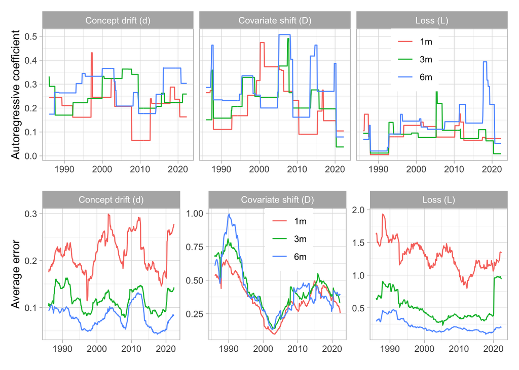

```r
rho_L <- data_reg1m$date %>%
  bind_cols(data.frame(rho_L)) %>% mutate(type = "Loss (L)")
colnames(rho_L) <- c("date", "1m", "3m", "6m", "type")
rho_D <- data_reg1m$date %>%
  bind_cols(data.frame(rho_D)) %>% mutate(type = "Covariate shift (D)")
colnames(rho_D) <- c("date", "1m", "3m", "6m", "type")
rho_d <- data_reg1m$date %>%
  bind_cols(data.frame(rho_d)) %>% mutate(type = "Concept drift (d)")
colnames(rho_d) <- c("date", "1m", "3m", "6m", "type")
ar1 <- bind_rows(rho_L, rho_D, rho_d) %>%
  filter(date > "1985-12-01") %>%     # There is a buffer period for the first estimation...
  pivot_longer(c("1m", "3m", "6m"), names_to = "sample", values_to = "value") %>%
  ggplot(aes(x = date, y = value, color = sample)) + geom_line() + facet_wrap(vars(type)) + theme_light() +
  theme(legend.position = c(0.8,0.83)) + ylab("Autoregressive coefficient") + xlab(element_blank())

d_t <- bind_cols(data_reg1m$date, data.frame(d_t))
D_t <- bind_cols(data_reg1m$date, data.frame(D_t))
colnames(d_t) <- c("date", "1m", "3m", "6m")
colnames(D_t) <- c("date", "1m", "3m", "6m")
d_t <- d_t %>% pivot_longer(-date, names_to = "sample", values_to = "value")
D_t <- D_t %>% pivot_longer(-date, names_to = "sample", values_to = "value")

er_L <- data_reg1m$date %>%
  bind_cols(data.frame(m_er_L)) %>% mutate(type = "Loss (L)")
colnames(er_L) <- c("date", "1m", "3m", "6m", "type")
er_D <- data_reg1m$date %>%
  bind_cols(data.frame(m_er_D)) %>% mutate(type = "Covariate shift (D)")
colnames(er_D) <- c("date", "1m", "3m", "6m", "type")
er_d <- data_reg1m$date %>%
  bind_cols(data.frame(m_er_d)) %>% mutate(type = "Concept drift (d)")
colnames(er_d) <- c("date", "1m", "3m", "6m", "type")

ar2 <- bind_rows(er_L, er_D, er_d) %>%
  filter(date > "1985-12-01") %>%
  pivot_longer(c("1m", "3m", "6m"), names_to = "sample", values_to = "value") %>%
  ggplot(aes(x = date, y = value, color = sample)) + geom_line() + facet_wrap(vars(type), scales = "free") + theme_light() +
  theme(legend.position = c(0.53,0.83)) + ylab("Average error") + xlab(element_blank())
ar1 / ar2
```

```r
# ggsave("ar2.pdf", width = 7, height = 4)
```